# 数据预处理——第二次作业

司徒雪颖

2017年10月30日

### 对比数据集flights中的变量dep_time，sched_dep_time，与dep_delay，看是否一致？

- 先查看缺失值情况

```r
library(nycflights13)
data(flights)
head(flights)
```

```
## # A tibble: 6 x 19
##    year month   day dep_time sched_dep_time dep_delay arr_time
##   <int> <int> <int>    <int>          <int>     <dbl>    <int>
## 1  2013     1     1      517            515         2      830
## 2  2013     1     1      533            529         4      850
## 3  2013     1     1      542            540         2      923
## 4  2013     1     1      544            545        -1     1004
## 5  2013     1     1      554            600        -6      812
## 6  2013     1     1      554            558        -4      740
## # ... with 12 more variables: sched_arr_time <int>, arr_delay <dbl>,
## #   carrier <chr>, flight <int>, tailnum <chr>, origin <chr>, dest <chr>,
## #   air_time <dbl>, distance <dbl>, hour <dbl>, minute <dbl>,
## #   time_hour <dttm>
```

```r
dim(flights)
```

```
## [1] 336776     19
```

```r
 #查看是否有缺失值
any(is.na(flights))
```

```
## [1] TRUE
```

```r
library(mice)
library(VIM)
md.pattern(flights)#查看缺失值情况
```

```
##        year month day sched_dep_time sched_arr_time flight distance hour
##  17294    1     1   1              1              1      1        1    1
## 310052    1     1   1              1              1      1        1    1
##     51    1     1   1              1              1      1        1    1
##     71    1     1   1              1              1      1        1    1
##    666    1     1   1              1              1      1        1    1
##    387    1     1   1              1              1      1        1    1
##   1044    1     1   1              1              1      1        1    1
##   7211    1     1   1              1              1      1        1    1
##           0     0   0              0              0      0        0    0
##        minute time_hour dep_time dep_delay arr_time arr_delay air_time
##  17294      1         1        1         1        1         1        1
## 310052      1         1        1         1        1         1        1
##     51      1         1        1         1        1         0        0
##     71      1         1        1         1        0         0        0
##    666      1         1        1         1        1         0        0
##    387      1         1        1         1        0         0        0
##   1044      1         1        0         0        0         0        0
##   7211      1         1        0         0        0         0        0
##             0         0     8255      8255     8713      9430     9430
##        carrier tailnum origin   dest
##  17294       1       0      0      0       3
## 310052       0       0      0      0       4
##     51       1       0      0      0       5
##     71       1       0      0      0       6
##    666       0       0      0      0       6
##    387       0       0      0      0       7
##   1044       1       0      0      0       8
##   7211       0       0      0      0       9
##         318316  336776 336776 336776 1372727
```

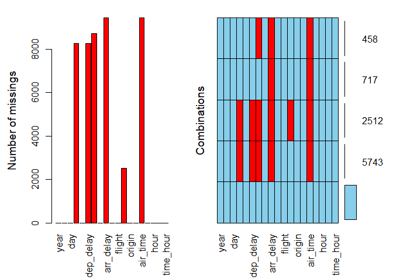

```r
aggr(flights, prop=FALSE, numbers=TRUE) #plot, more intuitional to display
```

```r
#dep_time dep_delay   8255缺失值
```

- 改成时间格式,方便dep_time，sched_dep_time相减

```r
library(lubridate)
library(dplyr)
make_datetime_100 <- function(year, month, day, time)
{
  make_datetime(year, month, day, time %/% 100, time %% 100)
}

flights_dt <-
  flights %>%
  filter(!is.na(dep_time), !is.na(dep_delay)) %>%
  mutate(
    dep_time = make_datetime_100(year, month, day, dep_time),
    sched_dep_time = make_datetime_100(year, month, day, sched_dep_time ),
    dep_delay2 = (dep_time-sched_dep_time)/60,
    weekday = wday(sched_dep_time))

head(flights_dt)
```

```
## # A tibble: 6 x 21
##    year month   day            dep_time      sched_dep_time dep_delay
##   <int> <int> <int>              <dttm>              <dttm>     <dbl>
## 1  2013     1     1 2013-01-01 05:17:00 2013-01-01 05:15:00         2
## 2  2013     1     1 2013-01-01 05:33:00 2013-01-01 05:29:00         4
## 3  2013     1     1 2013-01-01 05:42:00 2013-01-01 05:40:00         2
## 4  2013     1     1 2013-01-01 05:44:00 2013-01-01 05:45:00        -1
## 5  2013     1     1 2013-01-01 05:54:00 2013-01-01 06:00:00        -6
## 6  2013     1     1 2013-01-01 05:54:00 2013-01-01 05:58:00        -4
## # ... with 15 more variables: arr_time <int>, sched_arr_time <int>,
## #   arr_delay <dbl>, carrier <chr>, flight <int>, tailnum <chr>,
## #   origin <chr>, dest <chr>, air_time <dbl>, distance <dbl>, hour <dbl>,
## #   minute <dbl>, time_hour <dttm>, dep_delay2 <time>, weekday <dbl>
```

- 因为存在延误后第二天凌晨出发的航班，因此原定时间和飞机离开时间相减后,要加上1440min即24h，最终结果是全部相等

```r
sum(flights_dt$dep_delay!=flights_dt$dep_delay2 & flights_dt$dep_delay!=flights_dt$dep_delay2+1440)
```

```
## [1] 0
```

### 一天中不同时间点的平均延误时间是怎么样的？

- 一天中飞机最早起飞时间是凌晨5点，此时飞机平均延误时间最短，从5点开始至21点，飞机平均延误时长逐渐递增，在19,10,21点达到峰值，然后迅速下降。
- 对于飞机提早几分钟出发的情况，延误时间全部赋值为0，即没有延误。否则会使平均延误时间偏小

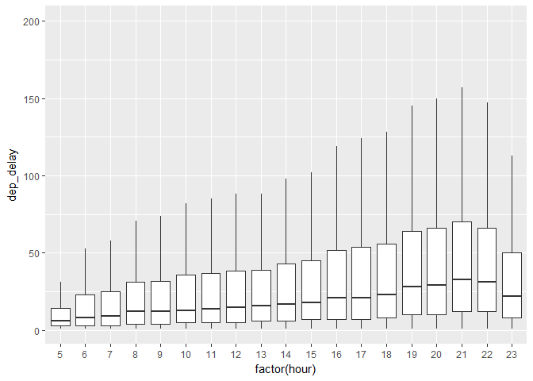

```r
library(ggplot2)
flights_dt$hour = factor(flights_dt$hour,levels = c(5:23))
flights_dt$dep_delay[flights_dt$dep_delay<0] = 0
#24小时与延误时长分布 箱线图
p = ggplot(flights_dt)+aes(x = factor(hour),y = dep_delay)
p+geom_boxplot(outlier.shape = NA, na.rm = T)+ylim(c(1,200))
```

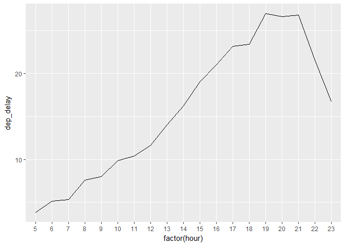

```r
#24小时与延误平均时长 折线图
p+aes(x = factor(hour),y = dep_delay,group = 1)+stat_summary(fun.y = "mean",geom = "line")
```

### 如果想要最小化飞机延误的概率，一周中哪天出行是最好的选择？

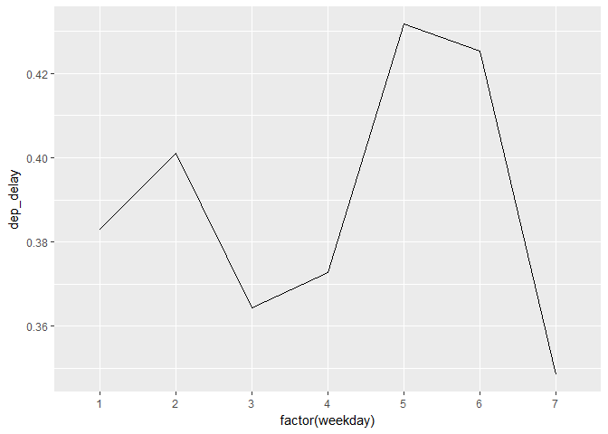

```r
#星期几与延误的概率
den = function(y) {sum(y>0)/length(y)}
p+aes(x = factor(weekday),y = dep_delay,group = 1)+stat_summary(fun.y = den,geom = "line")
```

### 在flights数据集中计算每个目的地机场的平均延误时间。

- 从flights数据中求得目的地机场及其平均延误时间，并与airports数据合并

```r
data("airports")
head(airports)
```

```
## # A tibble: 6 x 8
##     faa                           name      lat       lon   alt    tz
##   <chr>                          <chr>    <dbl>     <dbl> <int> <dbl>
## 1   04G              Lansdowne Airport 41.13047 -80.61958  1044    -5
## 2   06A  Moton Field Municipal Airport 32.46057 -85.68003   264    -6
## 3   06C            Schaumburg Regional 41.98934 -88.10124   801    -6
## 4   06N                Randall Airport 41.43191 -74.39156   523    -5
## 5   09J          Jekyll Island Airport 31.07447 -81.42778    11    -5
## 6   0A9 Elizabethton Municipal Airport 36.37122 -82.17342  1593    -5
## # ... with 2 more variables: dst <chr>, tzone <chr>
```

```r
ap_delay = aggregate(dep_delay~dest,data =flights_dt,mean)
flt_ap = merge(x = ap_delay,y = airports,by.x = "dest",by.y = "faa",all.x = T)
head(flt_ap)
```

```
##   dest dep_delay                              name      lat        lon
## 1  ABQ 16.047244 Albuquerque International Sunport 35.04022 -106.60919
## 2  ACK  9.822642                     Nantucket Mem 41.25305  -70.06018
## 3  ALB 26.095465                       Albany Intl 42.74827  -73.80169
## 4  ANC 13.125000        Ted Stevens Anchorage Intl 61.17436 -149.99636
## 5  ATL 15.055865   Hartsfield Jackson Atlanta Intl 33.63672  -84.42807
## 6  AUS 15.145988             Austin Bergstrom Intl 30.19453  -97.66989
##    alt tz dst             tzone
## 1 5355 -7   A    America/Denver
## 2   48 -5   A  America/New_York
## 3  285 -5   A  America/New_York
## 4  152 -9   A America/Anchorage
## 5 1026 -5   A  America/New_York
## 6  542 -6   A   America/Chicago
```

```r
library(maps)
states_map <- map_data("state")
head(states_map)
```

```
##        long      lat group order  region subregion
## 1 -87.46201 30.38968     1     1 alabama      <NA>
## 2 -87.48493 30.37249     1     2 alabama      <NA>
## 3 -87.52503 30.37249     1     3 alabama      <NA>
## 4 -87.53076 30.33239     1     4 alabama      <NA>
## 5 -87.57087 30.32665     1     5 alabama      <NA>
## 6 -87.58806 30.32665     1     6 alabama      <NA>
```

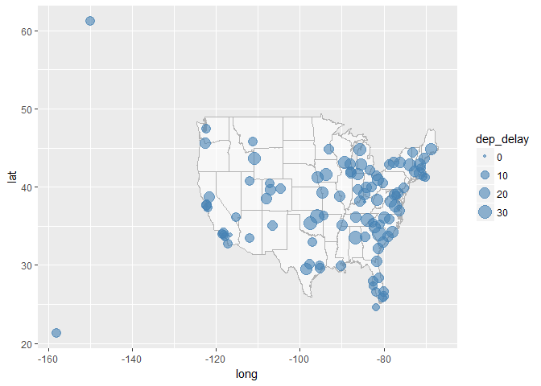

```r
ggplot() +
  geom_polygon(data = states_map, aes(x=long,y=lat,group=group),fill="white",colour="grey70",alpha=0.6) +
  geom_jitter(data=flt_ap, aes(x = lon,y = lat,size=dep_delay), colour="steelblue", alpha=0.6)
```

### 研究飞机的使用寿命与延误情况之间是否有关系？

- 合并flights与planes

```r
library(plyr)
data("planes")
head(planes)
```

```
## # A tibble: 6 x 9
##   tailnum  year                    type     manufacturer     model engines
##     <chr> <int>                   <chr>            <chr>     <chr>   <int>
## 1  N10156  2004 Fixed wing multi engine          EMBRAER EMB-145XR       2
## 2  N102UW  1998 Fixed wing multi engine AIRBUS INDUSTRIE  A320-214       2
## 3  N103US  1999 Fixed wing multi engine AIRBUS INDUSTRIE  A320-214       2
## 4  N104UW  1999 Fixed wing multi engine AIRBUS INDUSTRIE  A320-214       2
## 5  N10575  2002 Fixed wing multi engine          EMBRAER EMB-145LR       2
## 6  N105UW  1999 Fixed wing multi engine AIRBUS INDUSTRIE  A320-214       2
## # ... with 3 more variables: seats <int>, speed <int>, engine <chr>
```

```r
planes$age = 2013-planes$year
flt_pl = join(flights_dt,planes,by = "tailnum")
head(flt_pl)
```

```
##   year month day            dep_time      sched_dep_time dep_delay
## 1 2013     1   1 2013-01-01 05:17:00 2013-01-01 05:15:00         2
## 2 2013     1   1 2013-01-01 05:33:00 2013-01-01 05:29:00         4
## 3 2013     1   1 2013-01-01 05:42:00 2013-01-01 05:40:00         2
## 4 2013     1   1 2013-01-01 05:44:00 2013-01-01 05:45:00         0
## 5 2013     1   1 2013-01-01 05:54:00 2013-01-01 06:00:00         0
## 6 2013     1   1 2013-01-01 05:54:00 2013-01-01 05:58:00         0
##   arr_time sched_arr_time arr_delay carrier flight tailnum origin dest
## 1      830            819        11      UA   1545  N14228    EWR  IAH
## 2      850            830        20      UA   1714  N24211    LGA  IAH
## 3      923            850        33      AA   1141  N619AA    JFK  MIA
## 4     1004           1022       -18      B6    725  N804JB    JFK  BQN
## 5      812            837       -25      DL    461  N668DN    LGA  ATL
## 6      740            728        12      UA   1696  N39463    EWR  ORD
##   air_time distance hour minute           time_hour dep_delay2 weekday
```

[output cut: 20 more lines]

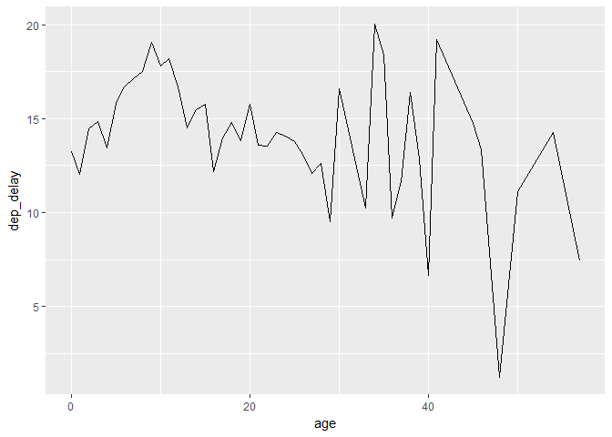

```r
# 飞机使用年限与平均延误时间
ggplot(flt_pl,aes(x = age,y = dep_delay))+stat_summary(fun.y = "mean",geom = "line",na.rm=T)
```

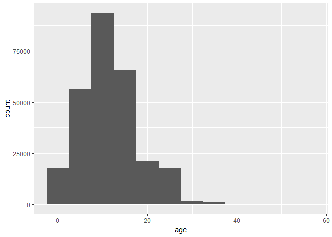

```r
#使用年限分布
ggplot(flt_pl)+geom_histogram(aes(age),binwidth = 5)
```

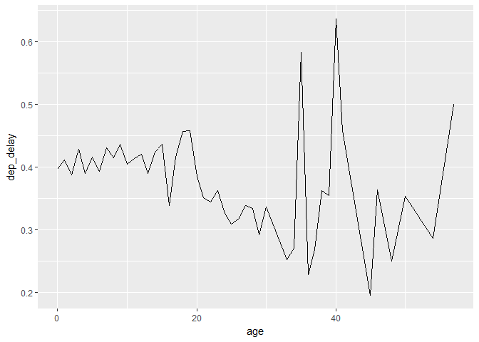

```r
#飞机使用年限与延误概率
ggplot(flt_pl,aes(x = age,y = dep_delay))+stat_summary(fun.y = den,geom = "line",na.rm=T)
```